# Police Shootings

Me, Myself, I

11/23/2020

## Association of mental illness with threat level and arms category

This section will be based on finding association rules in people with mental illness with the variables race, threat level and arms category. The three concepts used are support, confidence and lift. The formulas are given as

# Support

Support is an indication of how frequently the item set appears in the data set.

$$supp(X \Rightarrow Y)=\dfrac{|X \cup Y|}{n}$$

# Confidence

For a rule $X \Rightarrow Y$, confidence shows the percentage in which $Y$ is bought with $X$. It’s an indication of how often the rule has been found to be true.

$$conf(X \Rightarrow Y)=\dfrac{supp(X \cup Y)}{supp(X)}$$
# Lift

Lift is an indication of the usefulness of a rule. A ratio > 1 would mean that the rule’s consequence has a higher chance of occurring due to its antecedent compared to the entire population, and vice-versa. A ratio of 1 would imply that the rule is not useful as its probability in a resulting consequence is the same as the probability of getting that consequence in the entire population.

$$lift(X \Rightarrow Y)=\dfrac{supp(X \cup Y)}{supp(X) \times supp(Y)}$$

## R Markdown

```r
#Reading datasets
Shootings <- read.csv("shootings.csv",  sep=",")
```

```r
#Selecting the variables of interest
s_factor_all <- select(Shootings, gender, race, manner_of_death, arms_category, signs_of_mental_illness, threat_level)
summary(s_factor_all)
```

```
##     gender              race           manner_of_death    arms_category
##  Length:4895        Length:4895        Length:4895        Length:4895
##  Class :character   Class :character   Class :character   Class :character
##  Mode  :character   Mode  :character   Mode  :character   Mode  :character
##  signs_of_mental_illness threat_level
##  Length:4895             Length:4895
##  Class :character        Class :character
##  Mode  :character        Mode  :character
```

```r
#Turning the dataset into transactions class to be able to perform association rules and plotting
trans <- as(s_factor_all, "transactions")
summary(trans)
```

```
## transactions as itemMatrix in sparse format with
##  4895 rows (elements/itemsets/transactions) and
##  27 columns (items) and a density of 0.2222222
##
## most frequent items:
##                      gender=M          manner_of_death=shot
##                          4673                          4647
## signs_of_mental_illness=False           threat_level=attack
##                          3792                          3160
##            arms_category=Guns                       (Other)
##                          2764                         10334
##
## element (itemset/transaction) length distribution:
## sizes
##    6
## 4895
##
##    Min. 1st Qu.  Median    Mean 3rd Qu.    Max.
##       6       6       6       6       6       6
##
## includes extended item information - examples:
##       labels variables levels
## 1   gender=F    gender      F
## 2   gender=M    gender      M
## 3 race=Asian      race  Asian
##
## includes extended transaction information - examples:
##   transactionID
## 1             1
## 2             2
## 3             3
```

```r
itemLabels(trans)
```

```
##  [1] "gender=F"                            "gender=M"
##  [3] "race=Asian"                          "race=Black"
##  [5] "race=Hispanic"                       "race=Native"
##  [7] "race=Other"                          "race=White"
##  [9] "manner_of_death=shot"                "manner_of_death=shot and Tasered"
## [11] "arms_category=Blunt instruments"     "arms_category=Electrical devices"
## [13] "arms_category=Explosives"            "arms_category=Guns"
## [15] "arms_category=Hand tools"            "arms_category=Multiple"
## [17] "arms_category=Other unusual objects" "arms_category=Piercing objects"
## [19] "arms_category=Sharp objects"         "arms_category=Unarmed"
## [21] "arms_category=Unknown"               "arms_category=Vehicles"
## [23] "signs_of_mental_illness=False"       "signs_of_mental_illness=True"
## [25] "threat_level=attack"                 "threat_level=other"
## [27] "threat_level=undetermined"
```

```r
#most frequent items are "gender = M", "manner_of_death = shot", "signs_of_mental_illness=False", "arms_category=Guns", "race=White"
# gender and manner_of_death variables are then excluded from analysis because "gender = M" and "manner_of_death = shot" consist of 95% of the entire dataset.
# analysis can be done on the other variables by subsetting further
```

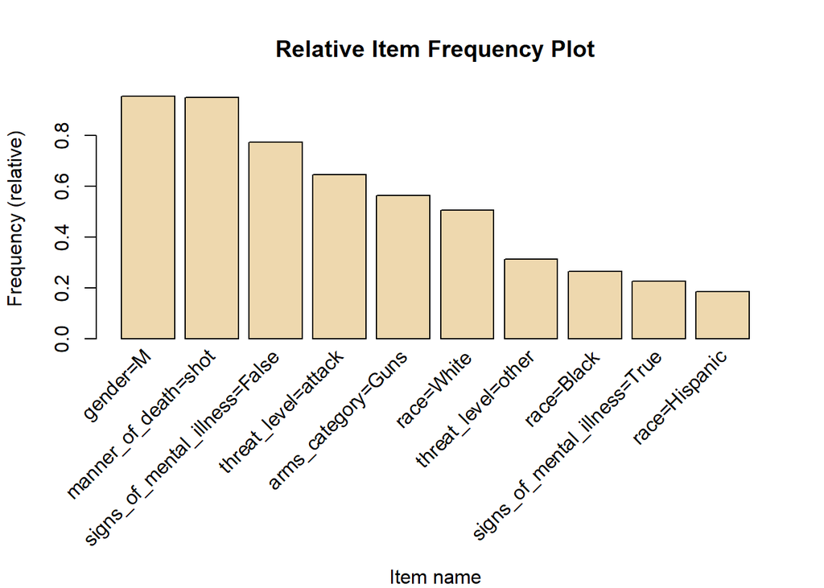

```r
#an item plot to visualise the relative item frequencies
itemFrequencyPlot(trans, topN=10, type="relative", col="wheat2",xlab="Item name",
                  ylab="Frequency (relative)", main="Relative Item Frequency Plot")
```

```r
#the first two items appear too frequently to provide any useful information
```

```r
# Removing gender and manner_of_death variables
s_factor_all <- s_factor_all %>% select(race, arms_category, signs_of_mental_illness, threat_level)
trans_main <- as(s_factor_all, "transactions")
summary(trans_main)
```

```
## transactions as itemMatrix in sparse format with
##  4895 rows (elements/itemsets/transactions) and
##  23 columns (items) and a density of 0.173913
##
## most frequent items:
## signs_of_mental_illness=False           threat_level=attack
##                          3792                          3160
##            arms_category=Guns                    race=White
##                          2764                          2476
##            threat_level=other                       (Other)
##                          1528                          5860
##
## element (itemset/transaction) length distribution:
## sizes
##    4
## 4895
##
##    Min. 1st Qu.  Median    Mean 3rd Qu.    Max.
##       4       4       4       4       4       4
##
## includes extended item information - examples:
##          labels variables   levels
## 1    race=Asian      race    Asian
## 2    race=Black      race    Black
## 3 race=Hispanic      race Hispanic
##
## includes extended transaction information - examples:
##   transactionID
## 1             1
## 2             2
## 3             3
```

```r
# The remaining four variables are Race, Arms Category, Signs of Mental Illness and Threat Level
```

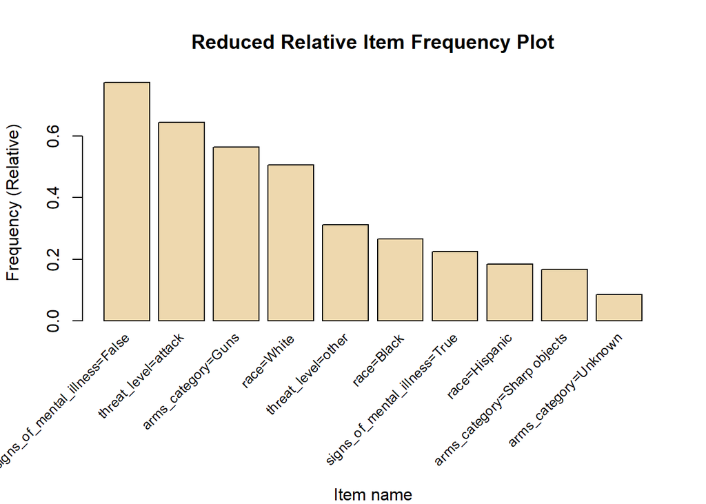

```r
# Reduced Relative Item Frequency Plot
itemFrequencyPlot(trans_main, topN=10, type="relative", col="wheat2",xlab="Item name",
                  ylab="Frequency (Relative)", main="Reduced Relative Item Frequency Plot", cex.names=.8)
```